# Cahpter 5

onyambu

10/8/2020

```python
import numpy as np
import matplotlib.pyplot as plt
```

# 5.1.11

Suppose we want to obtain the distribution of the quantity $Y=X^{4}+2 X^{3}-3$ when $X \sim N(0,1)$. Here we are faced with a form of mathematical uncertainty because it is very difficult to determine the distribution of $Y$ using mathematical methods. Propose a computer method for approximating the distribution function of $Y$ and estimate $P(Y \in(1,2)) .$ What is the relevance of statistical methodology to your approach?

## R

```r
Y <- function(x) x^4 + 2*x^3-3
x_sample <- rnorm(10000)
y_sample <- Y(x_sample)
mean(y_sample>=1 & y_sample<=2) #P(1<=Y<=2)
```

```
## [1] 0.018
```

# 5.4.11

Generate a sample of 1000 from an $N(3,2)$ distribution. ## (a) Calculate $\hat{F}_{X}$ for this sample.

### R

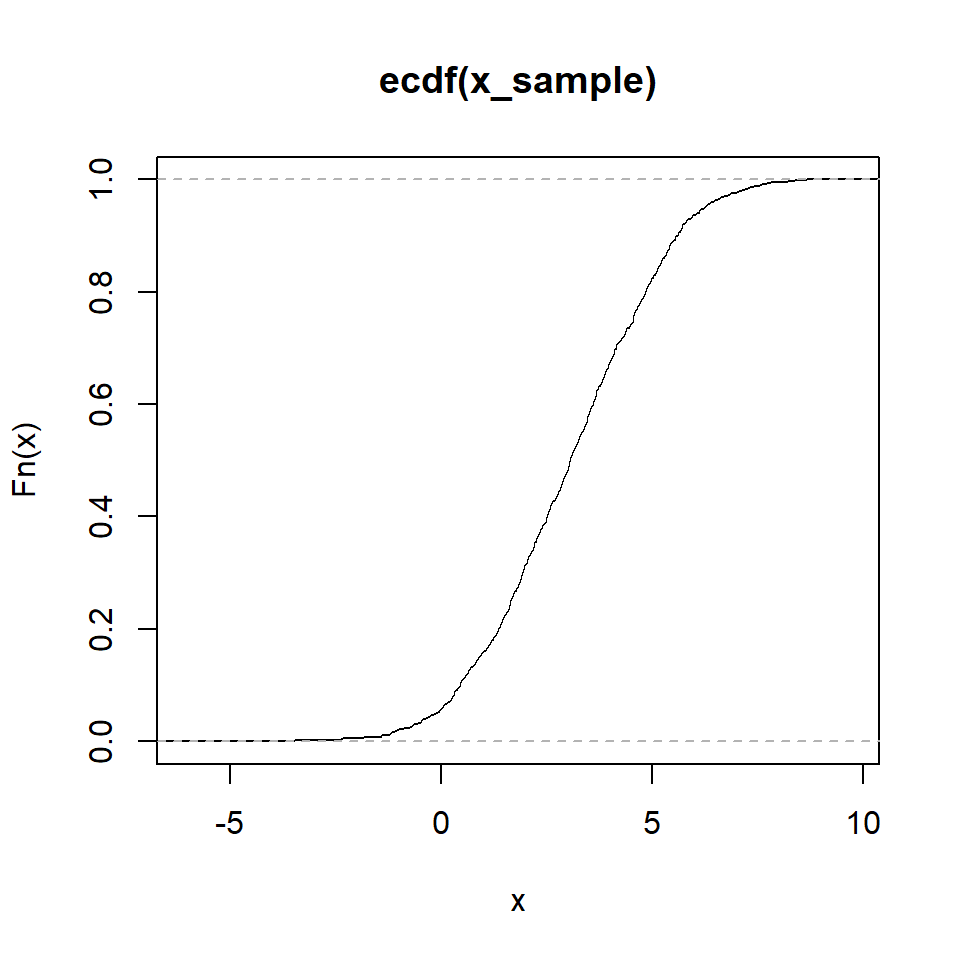

```r
x_sample <- rnorm(1000, 3, 2)
F_X <- ecdf(x_sample)
plot(F_X)
```

I have used `ecdf` function. What does that mean? It is an empirical cummulative distribution function. Look at how It is done in pytho to understand what ecdf does.

### Python

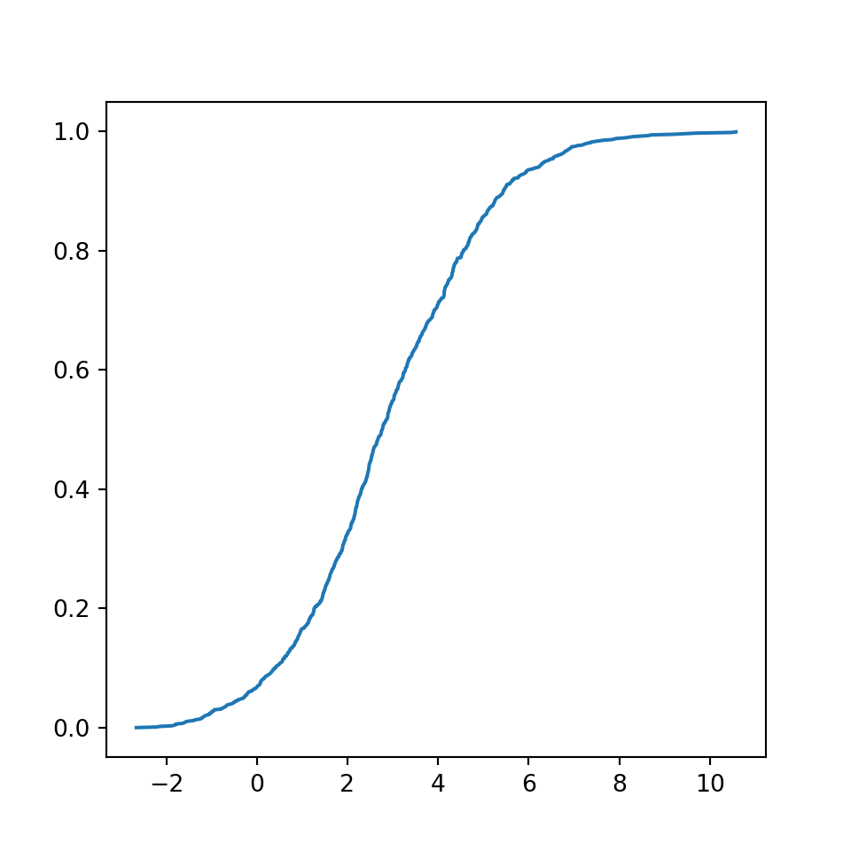

```python
x_sample = np.random.normal(loc = 3, scale = 2, size = 1000)
x_sample.sort()
y_sample = np.arange(x_sample.size)/x_sample.size
a=plt.plot(x_sample,y_sample)
plt.show()
```

## (b)

Plot a density histogram based on these data using the intervals of length 1 over the range (-5,10)

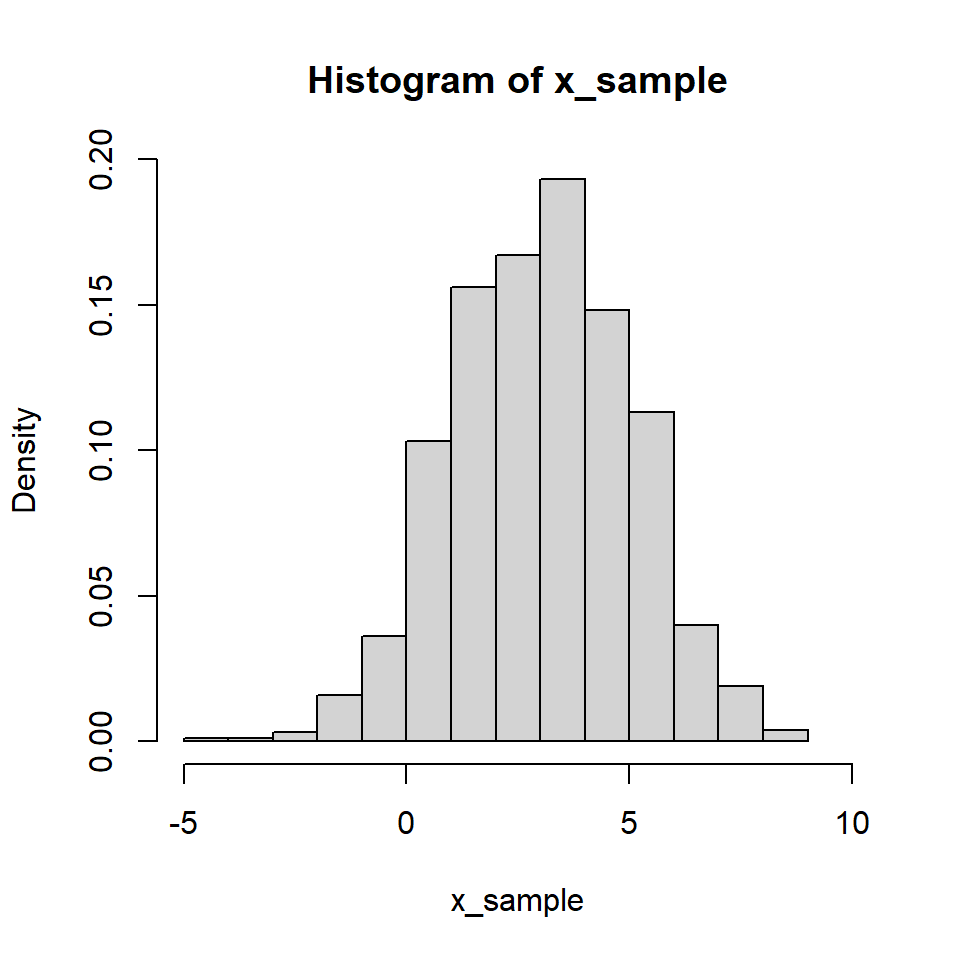

```r
hist(x_sample,freq = FALSE, xlim = c(-5,10), breaks = (10+5)/1)
```

### Python

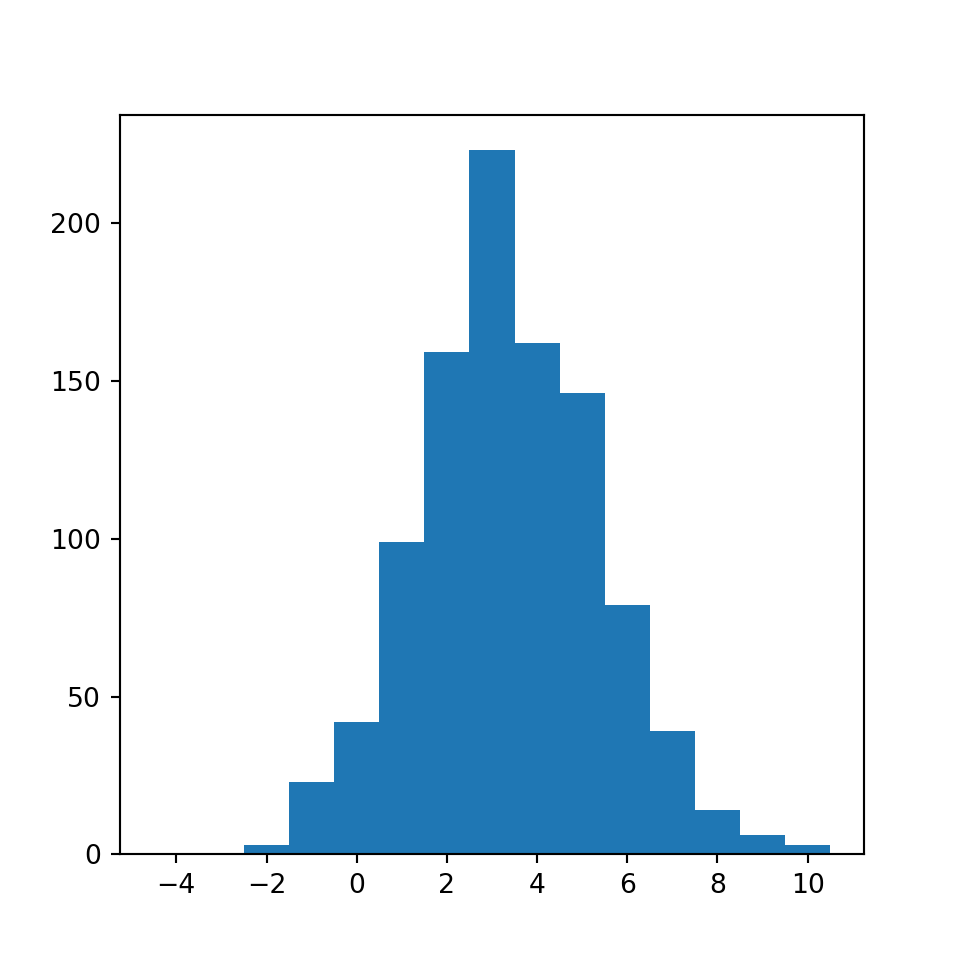

```python
a=plt.hist(x_sample, bins = 15, align="right", range = (-5, 10))
plt.show()
```

## (c)

Plot a density histogram based on these data using the intervals of length 0.1 over the range (-5,10)

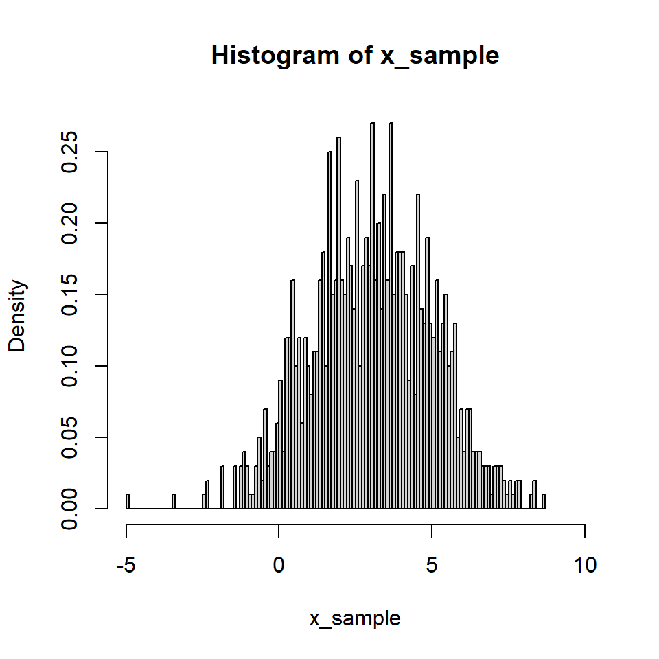

```r
hist(x_sample,freq = FALSE, xlim = c(-5,10), breaks = (10+5)/0.1)
```

### Python

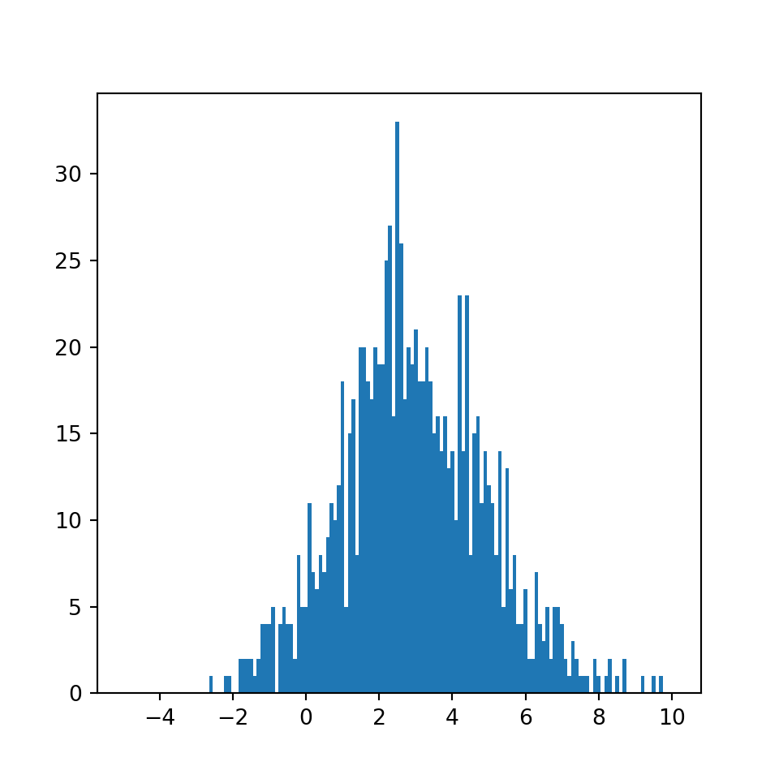

```python
a=plt.hist(x_sample, bins = 150, align="right", range = (-5, 10))
plt.show()
```

## (d)

Comment on the difference in the look of the histograms in parts (b) and (c). To what do you attribute this? – Binwidth selected. ## (e)

What limits the size of the intervals we use to group observations when we are plotting histograms?

Note: –Bins that are too wide can hide important details about distribution while bins that are too narrow can cause a lot of noise and hide important information about the distribution as well.

# 5.4.12

Suppose we have a population of 10,000 elements, each with a unique label from the set $\{1,2,3, \ldots, 10,000\}$

## (a)

Generate a sample of 500 labels from this population using simple random sampling.

### R

```r
srs_sample <- sample(x = 10000, size = 500)
```

### Python

```python
srs_sample = np.random.choice(a = 10000, size = 500, replace = False)
```

## (b)

Generate a sample of 500 labels from this population using i.i.d. sampling.

```r
iid_sample <- sample(x = 10000, size = 500, replace = TRUE)
```

### Python

```python
iid_sample = np.random.choice(a = 10000, size = 500)
```

# 5.5.18

Generate a sample of 30 from an $N(10,2)$ distribution and a sample of 1 from an $N(30,2)$ distribution. Combine these together to make a single sample of $31.$

## (a)

Produce a boxplot of these data.

### R

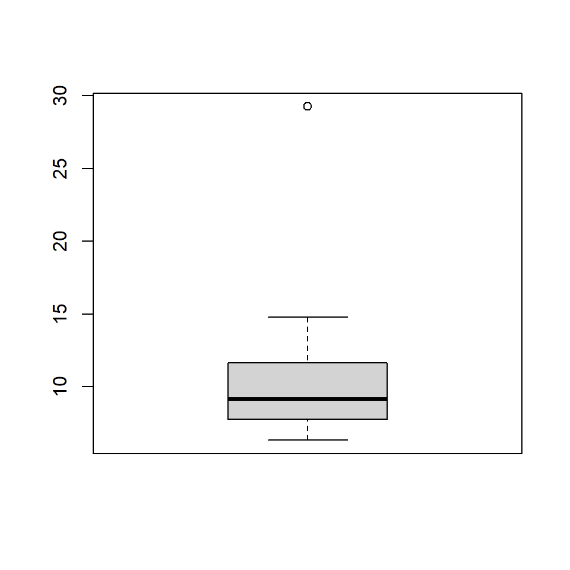

```r
my_sample <- c(rnorm(30, 10, 2), rnorm(1, 30, 2))
boxplot(my_sample)
```

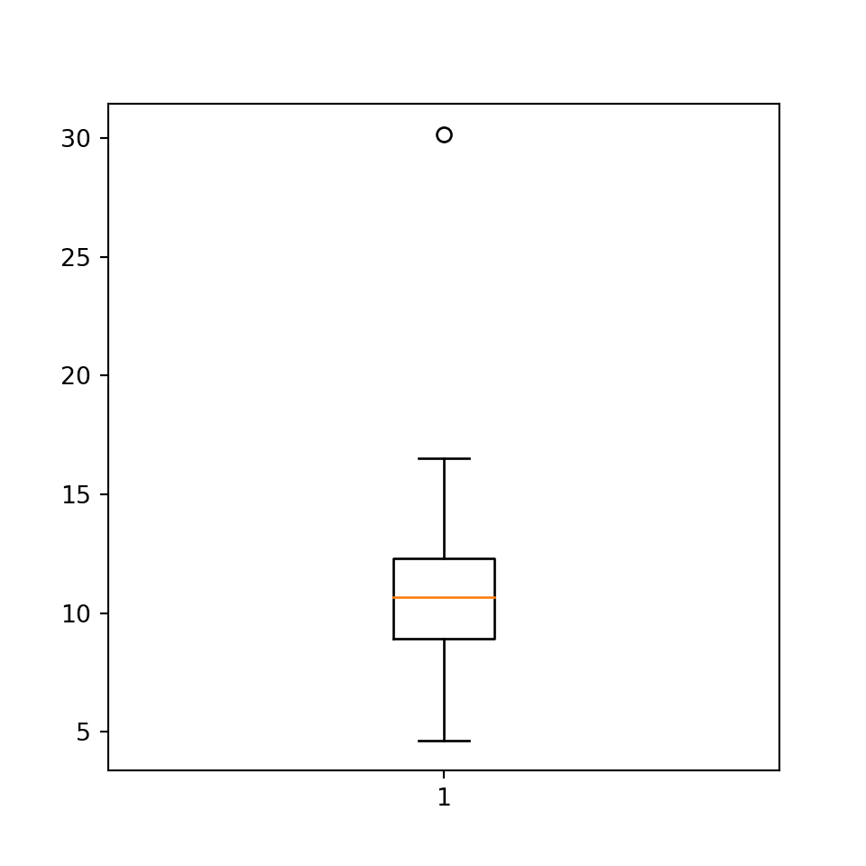

```python
my_sample = np.r_[np.random.normal(10,2,30), np.random.normal(30, 2, 1)]
a = plt.boxplot(my_sample)
plt.show()
```

## (b)

What do you notice about this plot? – Presence of an outlier

## (c)

Based on the boxplot, what characteristic do you think would be appropriate to measure the location and spread of the distribution? Explain why.

- location: Use Median
- Spread: IQR (Inter quartile range)

The two are not affected by outliers.